# pycon_col slides

```python
%matplotlib inline
```

## Presentaciones y encuestas interactivas con jupyter notebooks y RISE

### pycon Colombia 2020

### Sebastian Flores

**Observaciones:**

- sebastiandres en twitter y github.
- Presentación en github.com/sebastiandres/charlas
- Opiniones y críticas a título personal.

##### Introducción

¿Porqué esta presentación?

[figure not shown]

¿Se pueden hacer encuestas interactivas en presentaciones con jupyter notebooks?

##### Agenda

1. Sobre hacer presentaciones con RISE.
2. Solución 1: Quick & dirty.
3. Solución 2: ¡Pero quiero los datos!
4. Solución 3: No confío en nadie.

##### 0.1 Sobre hacer presentaciones con jupyter y RISE

¿Consejos sobre hacer presentaciones en general?

- Contenido pensado en tu audiencia.
- Ensayar, ensayar, ensayar.
- Incrementar el desafío.

##### 0.2 Sobre hacer presentaciones con jupyter y RISE

Si forma parte importante de tu día a día, investiga y aprende a hacer mejores presentaciones.

Libro que considero muy bueno: Confessions of a public speaker - Scott Berkum.

[figure not shown]

##### 0.3 Sobre hacer presentaciones con jupyter y RISE

¿jupyter notebook? ¿RISE?

[figure not shown]

##### 0.3 Sobre hacer presentaciones con jupyter y RISE

¿Qué es la extensión RISE?

Una celda de jupyter notebook se puede clasificar (adicionalmente al code/markdown) como:

- *Slide*: Diapositiva normal.
- *Fragment*: Fragmento de diapositiva.
- *Sub-slide*: Opcional.
- *Skip*: No mostrar.
- *Notes*: Notas.

Toda la info en https://rise.readthedocs.io/

##### 0.3 Sobre hacer presentaciones con jupyter y RISE

¿Qué es la extensión RISE?

[figure not shown]

##### 0.4 Sobre hacer presentaciones con jupyter y RISE

Ok, pero... ¿porqué? ¿Porqué? ¿PORQUÉ?

- Tener una presentación autocontenida: los ejemplos (código) queda en jupyter notebook.
- Corregir directamente cuando sea necesario.
- Hacer participar a la audiencia.

##### 0.4 Sobre hacer presentaciones con jupyter y RISE

Sí, incluso ejecutar código en python

```python
x = 200
y = 200
x is y
```

```
True
```

```python
a = 300
b = 300
a is b
```

```
False
```

```python
def cheeseburger(n):
    return ["bread"] + ["meat", "cheese"]*n + ["bread"]

cheeseburger(3)
```

```
['bread', 'meat', 'cheese', 'meat', 'cheese', 'meat', 'cheese', 'bread']
```

##### 0.5 Sobre hacer presentaciones con jupyter y RISE

¿Que he aprendido?

- Usa "Ctrl +" y "Ctrl -" para controlar aspecto.
- Entrega parte del control de contenido al público. Usa un teclado+mouse inalámbrico.
- Plantea desafíos de código incompleto pero entrega propuestas de solución.
- `git` es tu amigo.
- Improvisa. Nunca será como planificaste.

##### 0.6 Descripción del Problema

**¿Qué queremos?**

Realizar encuesta interactiva sin salir del modo presentación (en RISE).

**¿Porqué?**

Hacer encuestas para obtener retroalimentación de la audiencia cuando importa, sin cambiar pantalla o sistema.

##### 1.7 Descripción del Problema

**¿Se puede?**

Sí, y de varias maneras distintas.

**¿Cómo?**

IFrames.

##### 0.9 Descripción del Problema

Nuestro héroe se llama IFrame.

```python
from IPython.display import IFrame
IFrame("https://es.wikipedia.org/wiki/Iframe", width=1000, height=500) #https://es.wikipedia.org/wiki/Iframe
```

[interactive chart not shown]

Otros:

- https://www.pycon.co/
- https://rise.readthedocs.io/

##### 0.10 Descripción del Problema

Más ejemplos ...

```python
from IPython.display import IFrame
IFrame("https://www.python.org/", width=800, height=300)
```

[interactive chart not shown]

No siempre funciona:

- https://www.python.org/
- google, facebook, twitter, ...

En general a los sitios (sobre todo los que requieren autentificación y desean hacer tracking de usuarios) bloquean los IFrames.

##### 1.1 Problema: Realizar encuestas interactivas.

**Solucion nivel 1:**

KISS: Keep IT Simple, Stupid.

Podemos usar IFrame con los servicios de alguna compañía especializada en encuestas interactivas:

- Polleverywhere
- Mentimeter
- Muchos, muchos otros...

##### 1.2 Solución nivel 1: Encuesta

Probemos este método con una encuesta simple:

```python
from IPython.display import IFrame
IFrame("https://pollev.com/sebastianflo711", width=800, height=600)
```

[interactive chart not shown]

##### 1.3 Solución nivel 1:

Link encuesta:

https://pollev.com/sebastianflo711

**¿Qué debe cumplir un sitio de encuestas interactivas?**

- Encuesta acccesible por url pública, incrustable por iframe.
- Gráfico dinámico accesible por url pública, incrustable por iframe.

##### 1.3 Solución nivel 1:

Veamos los resultados de la encuesta anterior.

```python
from IPython.display import IFrame
IFrame("https://www.polleverywhere.com/multiple_choice_polls/7Xwy472JbCrk3fITm12XM", width=800, height=600)
# Observación: ¡requiere estar autentificado como dueño de la encuesta!
```

[interactive chart not shown]

##### 1.4 Solución nivel 1: Resumen

¿Cómo se debe usar?

1. Seleccionar algún proveedor.
2. Crear y configurar la encuesta previamente.
3. Obtener el enlace de las preguntas, e incrustarla con un iframe.
4. Obtener el gráfico de las respuestas, e incrustarla con un iframe.
5. Probar que funcione correctamente. Borrar respuestas de prueba.

##### 1.5 Pausa

¿Que viene antes, el huevo o la gallina?

```python
# Solución al problema
# python3 permite usar unicode
sorted(['\N{EGG}', '\N{CHICKEN}'])
```

```
['🐔', '🥚']
```

##### 2.1 Problema: Realizar encuestas interactivas.

**Solución Nivel 2**

Una segunda opción que requiere un poco más de configuración pero entrega más control, es usar un servicio de encuestas tradicional:

- Microsoft Forms
- Google Forms
- Survey Monkey
- Typeform
- Muchas otras...

Se diferencia que nosotros podemos hacer los gráficos porque podemos descargar los datos.

##### 2.2 Solución Nivel 2: Encuesta + Datos

Probemos este método con otra encuesta simple:

```python
long_url = "https://forms.office.com/Pages/ResponsePage.aspx?id=zu7OdUTRPU-clJ5rQCX8_4qs5cX1Y7dFhVdiCz848sBUNFU3UzU3OTNHVDhWNURSMEs2WDBUMDdCTi4u"
short_url = "https://bit.ly/2uYDdhm"
iframe_options = {"width":800, "height":600}
IFrame(short_url, **iframe_options)
```

[interactive chart not shown]

##### 2.3 Solución Nivel 2:

Link encuesta:

https://bit.ly/2uYDdhm

¿Qué debe cumplir un sitio de encuestas nivel 2?

- Encuesta accesible al público mediante un enlace abierto. Puede que no sea incrustable con un iframe.
- Opcionalmente, que cuente con gráficos en línea.
- Datos disponibles y puedan descargarse.
- Crear una función (en Python) para descargar e interpretar los datos.
- Probar que la encuesta funcione. Borrar las respuestas de prueba.

##### 2.4 Solución Nivel 2: Respuestas

```python
long_url = "https://forms.office.com/Pages/AnalysisPage.aspx?id=zu7OdUTRPU-clJ5rQCX8_4qs5cX1Y7dFhVdiCz848sBUNFU3UzU3OTNHVDhWNURSMEs2WDBUMDdCTi4u&AnalyzerToken=ND54U8Erls95gHxjbyWus4LzH6FPyZ35"
short_url = "https://bit.ly/37We2dE"
iframe_options = {"width":800, "height":600}
IFrame(short_url, **iframe_options)
```

[interactive chart not shown]

##### 2.4 Solución Nivel 2: Respuestas (versión 2)

- Descargamos la planilla de datos con el resultado desde algún enlace

```python
# Alternative to ls data/*.xlsx
import glob
glob.glob("data/*.xlsx")
```

```
['data/2020_02_08_encuesta2_pycon.xlsx']
```

```python
import pandas as pd
df_dict = pd.read_excel("data/2020_02_08_encuesta2_pycon.xlsx", sheet_name=None)
df_dict.keys()
```

```
odict_keys(['Hoja1', '_56F9DC9755BA473782653E2940F9', 'Form1'])
```

```python
df = df_dict["Form1"]
question = df.columns[-1]
print(question)
```

```
Which one is the best pet?
```

```python
df.head()
```

|  | ID | Start time | Completion time | Email | Name | Which one is the best pet? |
| --- | --- | --- | --- | --- | --- | --- |
| 0 | 9 | 2020-02-03 14:28:15 | 2020-02-03 14:28:27 | anonymous | NaN | Python |
| 1 | 10 | 2020-02-08 00:32:22 | 2020-02-08 00:32:27 | anonymous | NaN | Python |
| 2 | 11 | 2020-02-08 18:00:03 | 2020-02-08 18:00:08 | anonymous | NaN | Cat |
| 3 | 12 | 2020-02-08 18:00:04 | 2020-02-08 18:00:09 | anonymous | NaN | Cat |
| 4 | 13 | 2020-02-08 18:00:07 | 2020-02-08 18:00:12 | anonymous | NaN | Cat |

##### 2.5 Solución Nivel 2: Respuestas

```python
question_df = df[question]
answer_counts = question_df.value_counts()
answer_counts
```

```
Cat       9
Python    7
Dog       3
León      1
Pandas    1
RISE      1
Name: Which one is the best pet?, dtype: int64
```

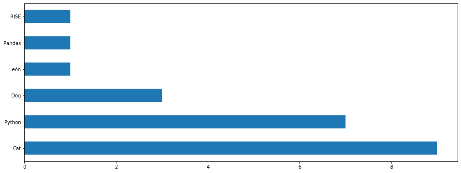

```python
from matplotlib import pyplot as plt
answer_counts.plot.barh(figsize=(16,6))
plt.show()
```

##### 2.6 Solución Nivel 2: Respuestas

Hagamos un gráfico un poco mejor.

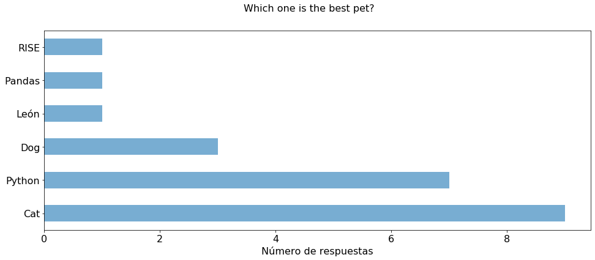

```python
from matplotlib import pyplot as plt
answer_counts.plot.barh(figsize=(16,6), fontsize=16, alpha=0.60)
plt.suptitle(question, fontsize=16)
plt.xlabel("Número de respuestas", fontsize=16)
plt.ylabel("");
```